# HW 3

Team 2

April 10, 2019

# Overview

Task: Explore, analyze and model a data set containing information on crime for various neighborhoods of a major city. Each record has a response variable indicating whether or not the crime rate is above the median crime rate (1) or not (0).

## Dependencies

For this project, we used Rstudio, ggplot2, and corrplot.

```r
#install.packages('corrplot')

require(ggplot2)
require(corrplot)
```

# Data Exploration

First we read the data as a csv then performed some simple statistical calculations so that we could explore the data. Below we can see the data as it was read from the csv.

```
##   zn indus chas   nox    rm   age    dis rad tax ptratio lstat medv target
## 1  0 19.58    0 0.605 7.929  96.2 2.0459   5 403    14.7  3.70 50.0      1
## 2  0 19.58    1 0.871 5.403 100.0 1.3216   5 403    14.7 26.82 13.4      1
## 3  0 18.10    0 0.740 6.485 100.0 1.9784  24 666    20.2 18.85 15.4      1
## 4 30  4.93    0 0.428 6.393   7.8 7.0355   6 300    16.6  5.19 23.7      0
## 5  0  2.46    0 0.488 7.155  92.2 2.7006   3 193    17.8  4.82 37.9      0
## 6  0  8.56    0 0.520 6.781  71.3 2.8561   5 384    20.9  7.67 26.5      0
```

We then calculated the mean and standard deviation for each data vector. Below is the result of those calculations.

```r
means <- sapply(training, mean)
sds   <- sapply(training, sd)
explore <- as.data.frame(cbind( means, sds))
explore
```

```
##                means         sds
## zn       11.57725322  23.3646511
## indus    11.10502146   6.8458549
## chas      0.07081545   0.2567920
## nox       0.55431052   0.1166667
## rm        6.29067382   0.7048513
## age      68.36759657  28.3213784
## dis       3.79569292   2.1069496
## rad       9.53004292   8.6859272
## tax     409.50214592 167.9000887
## ptratio  18.39849785   2.1968447
## lstat    12.63145923   7.1018907
## medv     22.58927039   9.2396814
## target    0.49141631   0.5004636
```

Below is a bar chart that illutrates the average and standard deviation for each of our data vectors. As we can see, the `tax` vector is a totally different magnitude than the rest. Models involving this vector will benefit from normalization or scaling.

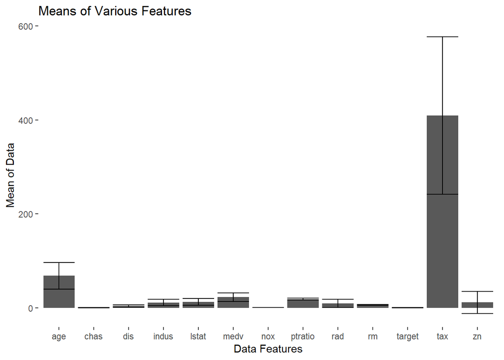

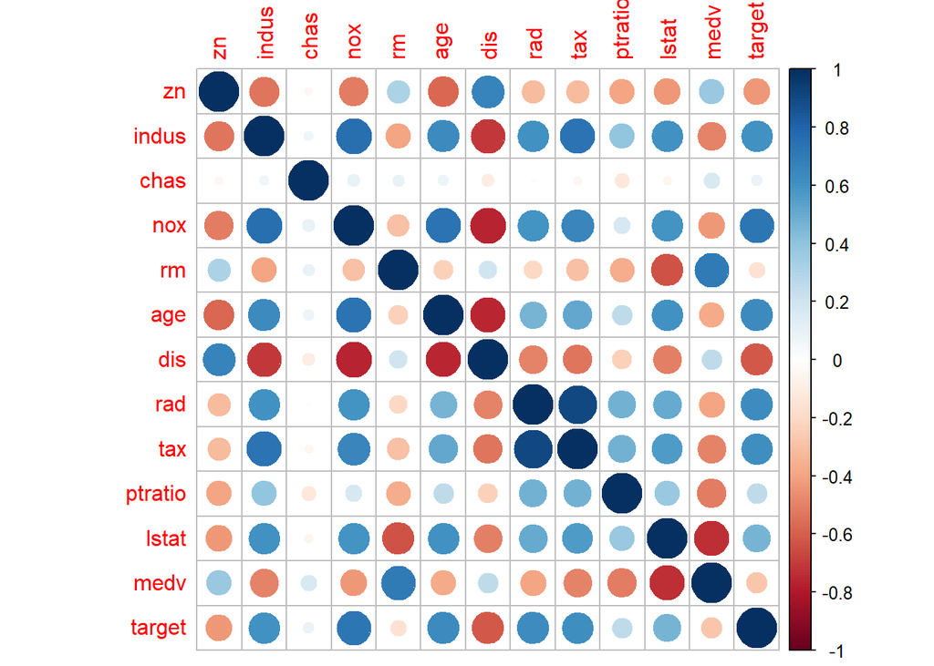

We can see that including rows without all of the data does not significantly effect the results.

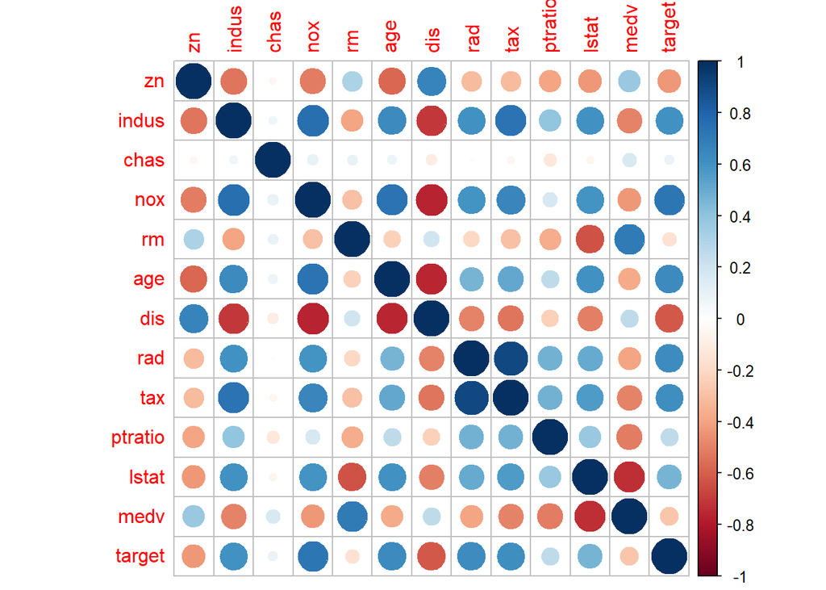

we can see how many `NAs` are in each column to see if we need to impute anything.

```r
apply(training, 2, function(x) length(!is.na(x)))
```

```
##      zn   indus    chas     nox      rm     age     dis     rad     tax
##     466     466     466     466     466     466     466     466     466
## ptratio   lstat    medv  target
##     466     466     466     466
```

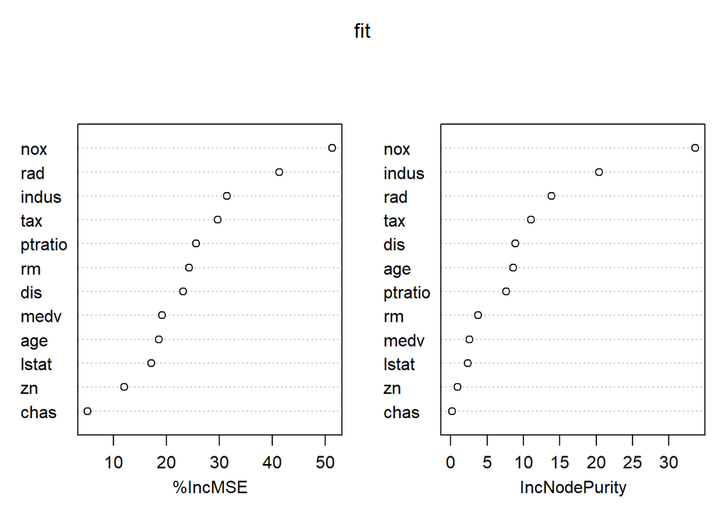

We verified our assumptions above using 1000 random forests. The `nox`, `rad`, `indus`, and `tax` have the most effect. While `dis`is strongly colinear, it has less effect on the target (likely due to it encoding information stored redundantly in another vector).

# Data Preparation

- [x] Fix missing Values (None!)
- [ ] Create Flags for missing variable
- [ ] Bin Data
- [ ] Transforms (BoxCox, etc)
- [ ] Combine Variables ?

# Build Models

- [ ] 3 binary logistic models
- [ ] forward, stepwise, random forest, etc
- [ ] Inferences
- [ ] Coefficients

# Select Models

- [ ] Use Log Likelihood, AIC, ROC curve,
- [ ] Evaluate Training Set
- [ ] Accuracy, Error, Precision, Sensitivity, Specificity, F1 score, AUC, conf matrix (hint: use assignment 2, and check out[this link](https://stackoverflow.com/questions/13548266/define-all-functions-in-one-r-file-call-them-from-another-r-file-how-if-pos) )
- [ ] Make predictions with test set and interpret